# Statistical inference with the GSS data

## Setup

### Load packages

```r
library(ggplot2)
library(dplyr)
library(statsr)
```

### Load data

Make sure your data and R Markdown files are in the same directory. When loaded your data file will be called `gss`. Delete this note when before you submit your work.

```r
load("gss.Rdata")
```

## Part 2: Research question

How does the Race correlate with discrimination and how far does it effects. This is in the light of the recent Events(BlackLivesMatter), and maybe this survey can throw some light into that matter.

## Part 3: Exploratory data analysis

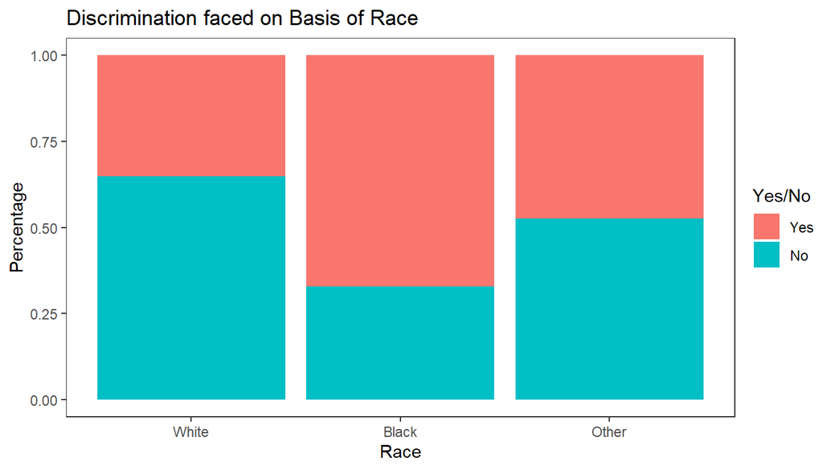

```r
race1<-as.data.frame(count(gss,var=race,racdif1))

race1<-na.omit(race1)

ggplot(race1) + geom_col(aes(x = var, y = n, fill = racdif1), position = "fill")+labs(title="Discrimination faced on Basis of Race",x="Race",y="Percentage",fill="Yes/No")+theme_test()
```

Above here we created a new data frame using as.data.frame and made a new data frame that contained the count between the Race and its response.  
After which a plot was prepared giving information regarding for various Races and their corresponding response percentage.  
It is visible that the people of Black Race face high level of Discrimination based on their Race while the people of White Race face less discrimination. Ofcourse this does not account the Not Available values,hence we will see more on this in the Inference part where more robust Statistics will be used and Tests like Chi-Square can provide more information on this.

## Part 4: Inference

Let our Null Hypothesis be

Ho: “There is no difference in Race of people and the people facing discrimination on basis of their Race”  
Ha: “There is a difference in Race Of People and the people facing discrimination on basis of their Race”  
Above in Data Analysis, we saw through the a basic diagram showing the percentages of people divided on race that whether they faced discrimination or not on the basis if their race.  
Here, we will use inferential statistics.

```r
gss2<-data.frame("Race"=gss$race,"RaceResp"=gss$racdif1)
inference(x = Race, y = RaceResp, data = gss2, statistic ="proportion", type = "ht", method = "simulation",alternative="greater")
```

```
## Response variable: categorical (2 levels)
## Explanatory variable: categorical (3 levels)
## Observed:
##        y
## x         Yes    No
##   White  6918 12712
##   Black  2047  1005
##   Other   665   739
##
## Expected:
##        y
## x             Yes         No
##   White 7848.4140 11781.5860
##   Black 1220.2425  1831.7575
##   Other  561.3435   842.6565
##
## H0: Race and RaceResp are independent
## HA: Race and RaceResp are dependent
## chi_sq = 1148.979, p_value = 5e-04
```

[figure not shown]

This high value of Chi Square Test Statistic is solid proof of that we can reject Ho(Null Hypothesis ) without any hesitation and accept the Ha(Alternative Hypothesis) that our Response Variable is dependent on the Explanatory Variable.

Hence, we can say that the Race Discrimination is faced on the basis dependent on the Race and the Exploratory Data Analysis shows that the White Race faces some privileges against discrimination and on the other hand the Black Race and Other races face more discrimination on basis of Race.

These can be regarded as in USA people White Race People have some privileges, while the Black Race people are still being discriminated.

*To clarify, the null hypothesis, states that the discrimination on Basis of Race is independent of Race, that regardless of the Race, the discrimination on Race will/should be same for all Races, that is all the Races will face same degree of Discrimination on basis of race.*

*And the alternative hypothesis, states that discrimination on Race is dependent on the Race and a specific race may face more Discrimination on Basis of Race compared to other race.*

And the above inference and the data analysis shows that the White Race people are being less discriminated than the other races, while the Black Race is being most discriminated.